with robust modeling, spatial CV, and land-cover physics

Author

gisma

# 1 Why the PipeModel?

The **PipeModel** is a deliberately idealized yet physically plausible valley scenario. It distills terrain to the essentials (parabolic cross-valley profile) and optional features (left-side hill, right-side pond or hollow), so that dominant **microclimate drivers** become visible and testable:

You can sample synthetic stations, train interpolators (IDW, Kriging variants, RF, GAM), and assess them with **spatial LBO-CV**.

> 🔧 This document keeps the previous behaviour but extends the physics with a modular **land-cover layer** that feeds into both daytime and night fields.

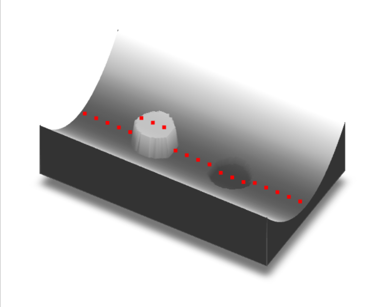

```r
# Crisp figures
# EN: Crisp figures
knitr::opts_chunk$set(fig.width = 9, fig.height = 6, dpi = 150)
# Alle Chunk-Meldungen global weg
# EN: Silence messages/warnings in all chunks
knitr::opts_chunk$set(message = FALSE, warning = FALSE)

# Hilfsfunktion: gstat & Co. ruhigstellen
# EN: Helper: silence gstat & friends
quiet <- function(expr) suppressWarnings(suppressMessages(force(expr)))
```

## 1.1 Helper function cheat-sheet

[output not shown]

# 2 A. Setup & global knobs

```r
# Packages ---------------------------------------------------------------
req_pkgs <- c(
  "terra","sf","ggplot2","dplyr","tibble","tidyr",
  "suncalc","gstat","randomForest","mgcv","scales","patchwork",
  "knitr","kableExtra","RColorBrewer", "zoo"
)
inst <- rownames(installed.packages())
if (any(!req_pkgs %in% inst)) install.packages(setdiff(req_pkgs, inst), dependencies = TRUE)
invisible(lapply(req_pkgs, require, character.only = TRUE))
sf::sf_use_s2(FALSE)  # robust joins in small projected domains
set.seed(42)

`%||%` <- function(a, b) if (!is.null(a)) a else b

# Domain & grid ---------------------------------------------------------
crs_utm <- "EPSG:32632"
E0 <- 600000; N0 <- 5725000
len_x <- 1200; len_y <- 800; res <- 2
ext <- terra::ext(E0 - len_x/2, E0 + len_x/2, N0 - len_y/2, N0 + len_y/2)
Rtemplate <- terra::rast(ext, resolution = res, crs = crs_utm)

xmin <- terra::xmin(ext); xmax <- terra::xmax(ext)
ymin <- terra::ymin(ext); ymax <- terra::ymax(ext)
x0 <- (xmin+xmax)/2;      y0 <- (ymin+ymax)/2

# Feature anchors (left/right thirds) ----------------------------------
x_hill_center <- xmin + len_x/3;   y_hill_center <- y0
x_lake_center <- xmin + 2*len_x/3; y_lake_center <- y0

# Scenario toggles ------------------------------------------------------
lake_choice <- "water"   # "none" | "water" | "hollow"
hill_choice <- "bump"    # "none" | "bump"

# Feature geometry
lake_diam_m  <- 80; lake_depth_m <- 10; smooth_edges <- FALSE
hill_diam_m  <- 80; hill_height_m <- 50; hill_smooth  <- FALSE

# Night pooling reduction over hill (0..1)
pool_block_gain <- 0.4

no_random_hill = 9

# Stations --------------------------------------------------------------
station_mode      <- "random"     # "random" | "ns_transect" | "ew_transect"
n_st              <- 60
transect_margin_m <- 10
ns_offset_m <- 0   # + east / - west
ew_offset_m <- 0   # + north / - south

# CV & models -----------------------------------------------------------
# --- Global einheitlich ---
compute_block_size <- function(len_x, len_y, n_st,
                               target_st_per_block = 3,
                               min_blocks_axis = 3,
                               round_to = 50) {
  area <- len_x * len_y
  B_target <- max(min_blocks_axis^2, round(n_st / target_st_per_block))
  bs <- sqrt(area / B_target)                         # idealisierte Blockkante
  bs <- min(bs, len_x / min_blocks_axis, len_y / min_blocks_axis)  # mind. 3 pro Achse
  bs <- max(round_to, round(bs / round_to) * round_to)             # "schön" runden
  as.integer(bs)
}

# anwenden
block_size  <- compute_block_size(len_x, len_y, n_st)


.get_block_size <- function() {
  bs <- get0("block_size", ifnotfound = 100)
  if (!is.numeric(bs) || !is.finite(bs) || bs <= 0) 100 else as.numeric(bs)
}
models_use <- c("Voronoi","IDW","OK","KED","RF","GAM")

# Viz palettes ----------------------------------------------------------
temp_palette <- grDevices::colorRampPalette(c("#0000FF","#FF0000"))(256)  # blue->red
stretch_q    <- c(0.02, 0.98)
```

# 3 B. LAndscape Modeler

```r
# Domain diagonal (used for variogram fallbacks)
dom_diag <- sqrt((xmax - xmin)^2 + (ymax - ymin)^2)

lat <- 51.8; lon <- 10.6
sun_pos_utc <- function(y, m, d, h, lat, lon) {
  t  <- as.POSIXct(sprintf("%04d-%02d-%02d %02d:00:00", y, m, d, h), tz = "UTC")
  sp <- suncalc::getSunlightPosition(date = t, lat = lat, lon = lon)
  az_from_north <- (sp$azimuth + pi) %% (2*pi)
  list(alt = sp$altitude, az = az_from_north)
}
sun14 <- sun_pos_utc(2024, 6, 21, 14, lat, lon)
sun05 <- sun_pos_utc(2024, 6, 21,  5, lat, lon)

# Cosine of incidence (sun on slope/aspect)
cosi_fun <- function(alt, az, slp_r, asp_r) {
  zen <- (pi/2 - alt)
  ci  <- cos(slp_r)*cos(zen) + sin(slp_r)*sin(zen)*cos(az - asp_r)
  terra::ifel(ci < 0, 0, ci)
}
```

# 4 C. Model builder (modular) — topo + land-cover + physics

We separate builder logic into three parts:

```r
# 1) Topography ---------------------------------------------------------
# 1) Topography ---------------------------------------------------------
build_topography <- function(lake_mode = c("none","water","hollow"),
                             hill_mode = c("none","bump")) {
  lake_mode <- match.arg(lake_mode); hill_mode <- match.arg(hill_mode)
  XY <- as.data.frame(terra::xyFromCell(Rtemplate, 1:terra::ncell(Rtemplate))); names(XY) <- c("x","y")
  dy <- XY$y - y0
  a  <- 100 / ((len_y/2)^2)              # ~100 m rim height
  elev <- 500 + a * dy^2

  # Pond/hollow (right third)
  rl <- sqrt((XY$x - x_lake_center)^2 + (XY$y - y_lake_center)^2); lr <- lake_diam_m/2
  if (lake_mode %in% c("water","hollow")) {
    w_l <- if (smooth_edges) pmax(0, 1 - (rl/lr)^2) else as.numeric(rl <= lr)
    elev <- elev - lake_depth_m * w_l
  } else w_l <- 0

  # Hill (left third)
  if (hill_mode == "bump") {
    rh <- sqrt((XY$x - x_hill_center)^2 + (XY$y - y_hill_center)^2); hr <- max(1e-6, hill_diam_m/2)
    w_h <- if (hill_smooth) exp(- (rh/hr)^2) else as.numeric(rh <= hr)
    elev <- elev + hill_height_m * w_h
  } else w_h <- 0

  E <- Rtemplate; terra::values(E) <- elev; names(E) <- "elev"
  lakeR <- Rtemplate; terra::values(lakeR) <- if (lake_mode=="water") as.numeric(w_l>0) else 0; names(lakeR) <- "lake"
  hillW <- Rtemplate; terra::values(hillW) <- if (hill_mode=="bump") w_h else 0; names(hillW) <- "hillW"

  # Derivatives & sun
  slp  <- terra::terrain(E, v="slope",  unit="radians")
  asp  <- terra::terrain(E, v="aspect", unit="radians")
  slp0 <- terra::ifel(is.na(slp), 0, slp); asp0 <- terra::ifel(is.na(asp), 0, asp)
  I14  <- cosi_fun(sun14$alt, sun14$az, slp0, asp0)
  I05  <- cosi_fun(sun05$alt, sun05$az, slp0, asp0)

  list(E = E, lake = lakeR, hillW = hillW, slp = slp0, asp = asp0, I14 = I14, I05 = I05)
}


# 2) Land-cover ---------------------------------------------------------
# --- Land-Cover: zentrale Definition (1 forest, 2 water, 3 bare soil, 4 maize)
lc_levels_default <- c("forest","water","bare soil","maize")
lc_levels <- getOption("pipemodel.lc_levels", lc_levels_default)
lc_colors <- c("forest"="#2E8B57","water"="#5DADE2","bare soil"="#C49A6C","maize"="#F4D03F")
lc_colors_default <- c(
  "forest"          = "#2E8B57",
  "water"        = "#5DADE2",
  "bare soil"  = "#C49A6C",
  "maize"          = "#F4D03F"
)

# 2) Land-cover ---------------------------------------------------------
# --- Land-Cover: zentrale Definition (1 forest, 2 water, 3 bare soil, 4 maize)
lc_levels_default <- c("forest","water","bare soil","maize")
lc_levels <- getOption("pipemodel.lc_levels", lc_levels_default)
lc_colors <- c("forest"="#2E8B57","water"="#5DADE2","bare soil"="#C49A6C","maize"="#F4D03F")
lc_colors_default <- c(
  "forest"          = "#2E8B57",
  "water"        = "#5DADE2",
  "bare soil"  = "#C49A6C",
  "maize"          = "#F4D03F"
)
# 3) Physics: T14/T05 from topo + land-cover ----------------------------
# Day: solar sensitivity (alpha_I) and canopy shading factor for cos(i)
alpha_I_by_lc <- c("forest"=3.5, "water"=1.5, "bare soil"=6.0, "maize"=4.5)
shade_fac_by_lc <- c("forest"=0.6, "water"=1.0, "bare soil"=1.0, "maize"=0.9)
# Dawn: additive warm/cool biases (°C) + pooling modifiers (multiplier)
dawn_bias_by_lc <- c("forest"=0.3, "water"=1.2, "bare soil"=-0.5, "maize"=0.1)
pool_fac_by_lc  <- c("forest"=0.7, "water"=0.8, "bare soil"=1.1, "maize"=1.0)

# Koeffizienten (benannte Vektoren in Deutsch; nur falls nicht schon definiert)
if (!exists("alpha_I_by_lc")) {
  alpha_I_by_lc <- c("forest"=3.5,"water"=1.5,"bare soil"=6.0,"maize"=4.5)
}
if (!exists("shade_fac_by_lc")) {
  shade_fac_by_lc <- c("forest"=0.6,"water"=1.0,"bare soil"=1.0,"maize"=0.9)
}
if (!exists("dawn_bias_by_lc")) {
  dawn_bias_by_lc <- c("forest"=0.3,"water"=1.2,"bare soil"=-0.5,"maize"=0.1)
}
if (!exists("pool_fac_by_lc")) {
  pool_fac_by_lc  <- c("forest"=0.7,"water"=0.8,"bare soil"=1.1,"maize"=1.0)
}

# ------------------------------------------------------------------------------
# build_physics_fields(topography, landcover, noise14, noise05)
# Purpose:
#   Create the synthetic temperature "truth" fields for day (T14) and pre-dawn (T05)
#   using topography, land-cover-dependent coefficients, solar geometry, and small noise.
# Inputs:
#   - topography: list containing E, slp, I14, I05, hillW (from build_topography or scenario).
#   - landcover:  SpatRaster (or list with lc) of integer LC codes (1..4) per cell.
#   - noise14/noise05: SpatRasters with Gaussian noise to add small texture.
# Model (kept exactly as in code):
#   T14 = T0_14 + lapse_14*(E - mean(E)) + alpha_I(LC) * (I14 * shade_fac(LC)) + noise
#   T05 = T0_05 + inv_05 *(E - mean(E)) + eta_slope * slope
#                  - pool_base*(1 - pool_block_gain*hillW)*pool_fac(LC)
#                  + dawn_bias(LC) + noise
# Returns:
#   list(R14 = T14 raster, R05 = T05 raster), names preserved exactly.
# ------------------------------------------------------------------------------
build_physics_fields <- function(topography, landcover, noise14, noise05) {
  E    <- topography$E
  slp0 <- topography$slp
  I14  <- topography$I14
  I05  <- topography$I05
  hillW<- topography$hillW

  # accept either a list(list(lc=...)) or a SpatRaster directly
  lc <- if (inherits(landcover, "SpatRaster")) landcover else landcover$lc
  stopifnot(inherits(lc, "SpatRaster"))

  # lc (numerisch 1..4) -> Zeichenklassen gemäß lc_levels
  v  <- as.integer(terra::values(lc))
  v[!is.finite(v)] <- 1L
  v <- pmax(1L, pmin(v, length(lc_levels)))
  lc_char <- factor(lc_levels[v], levels = lc_levels)

  # Karten aus benannten Vektoren ableiten
  to_r <- function(x) terra::setValues(terra::rast(E), x)
  alpha_I <- to_r(as.numeric(alpha_I_by_lc[lc_char]))
  shade_f <- to_r(as.numeric(shade_fac_by_lc[lc_char]))
  dawn_b  <- to_r(as.numeric(dawn_bias_by_lc[lc_char]))
  pool_f  <- to_r(as.numeric(pool_fac_by_lc[lc_char]))

  # Effektive Strahlung (forest beschattet)
  I14_eff <- I14 * shade_f
  I05_eff <- I05 * shade_f  # der Vollständigkeit halber
```

```r
  # Baselines
  E_mean <- terra::global(E, "mean", na.rm = TRUE)[1,1]
  Y <- terra::init(E, "y"); dist2ax <- abs(Y - (terra::ymax(E)+terra::ymin(E))/2); w_pool <- 70
  pool_base <- 4.0 * exp(- (dist2ax / w_pool)^2)
  pool_mod  <- pool_base * (1 - pool_block_gain * hillW) * pool_f

  # Tag (14 UTC)
  T0_14 <- 26.0; lapse_14 <- -0.0065
  R14 <- T0_14 + lapse_14 * (E - E_mean) + alpha_I * I14_eff + noise14; names(R14) <- "T14"

  # Nacht/Früh (05 UTC)
  T0_05 <- 8.5; inv_05 <- 0.003; eta_slope <- 0.6
  R05 <- T0_05 + inv_05 * (E - E_mean) + eta_slope * slp0 - pool_mod + dawn_b + noise05; names(R05) <- "T05"

  list(R14 = R14, R05 = R05)
}


# Noise rasters (generated once) --------------------------------------
set.seed(1001)
noise14_r <- terra::setValues(terra::rast(Rtemplate), rnorm(terra::ncell(Rtemplate), 0, 0.3))
set.seed(1002)
noise05_r <- terra::setValues(terra::rast(Rtemplate), rnorm(terra::ncell(Rtemplate), 0, 0.3))

# ------------------------------------------------------------------------------
# build_physics_fields(topography, landcover, noise14, noise05)
# Purpose:
#   Create the synthetic temperature "truth" fields for day (T14) and pre-dawn (T05)
#   using topography, land-cover-dependent coefficients, solar geometry, and small noise.
# Inputs:
#   - topography: list containing E, slp, I14, I05, hillW (from build_topography or scenario).
#   - landcover:  SpatRaster (or list with lc) of integer LC codes (1..4) per cell.
#   - noise14/noise05: SpatRasters with Gaussian noise to add small texture.
# Model (kept exactly as in code):
#   T14 = T0_14 + lapse_14*(E - mean(E)) + alpha_I(LC) * (I14 * shade_fac(LC)) + noise
#   T05 = T0_05 + inv_05 *(E - mean(E)) + eta_slope * slope
#                  - pool_base*(1 - pool_block_gain*hillW)*pool_fac(LC)
#                  + dawn_bias(LC) + noise
# Returns:
#   list(R14 = T14 raster, R05 = T05 raster), names preserved exactly.
# ------------------------------------------------------------------------------
build_physics_fields <- function(topography, landcover, noise14, noise05) {
  E    <- topography$E
  slp0 <- topography$slp
  I14  <- topography$I14
  I05  <- topography$I05
  hillW<- topography$hillW

  # accept either a list(list(lc=...)) or a SpatRaster directly
  lc <- if (inherits(landcover, "SpatRaster")) landcover else landcover$lc
  stopifnot(inherits(lc, "SpatRaster"))

  # lc (numerisch 1..4) -> Zeichenklassen gemäß lc_levels
  v  <- as.integer(terra::values(lc))
  v[!is.finite(v)] <- 1L
  v <- pmax(1L, pmin(v, length(lc_levels)))
  lc_char <- factor(lc_levels[v], levels = lc_levels)

  # Karten aus benannten Vektoren ableiten
  to_r <- function(x) terra::setValues(terra::rast(E), x)
  alpha_I <- to_r(as.numeric(alpha_I_by_lc[lc_char]))
  shade_f <- to_r(as.numeric(shade_fac_by_lc[lc_char]))
  dawn_b  <- to_r(as.numeric(dawn_bias_by_lc[lc_char]))
  pool_f  <- to_r(as.numeric(pool_fac_by_lc[lc_char]))

  # Effektive Strahlung (forest beschattet)
  I14_eff <- I14 * shade_f
  I05_eff <- I05 * shade_f  # der Vollständigkeit halber

  # Baselines
  E_mean <- terra::global(E, "mean", na.rm = TRUE)[1,1]
  Y <- terra::init(E, "y"); dist2ax <- abs(Y - (terra::ymax(E)+terra::ymin(E))/2); w_pool <- 70
  pool_base <- 4.0 * exp(- (dist2ax / w_pool)^2)
  pool_mod  <- pool_base * (1 - pool_block_gain * hillW) * pool_f

  # Tag (14 UTC)
  T0_14 <- 26.0; lapse_14 <- -0.0065
  R14 <- T0_14 + lapse_14 * (E - E_mean) + alpha_I * I14_eff + noise14; names(R14) <- "T14"

  # Nacht/Früh (05 UTC)
  T0_05 <- 8.5; inv_05 <- 0.003; eta_slope <- 0.6
  R05 <- T0_05 + inv_05 * (E - E_mean) + eta_slope * slp0 - pool_mod + dawn_b + noise05; names(R05) <- "T05"

  list(R14 = R14, R05 = R05)
}

# Noise rasters (generated once) --------------------------------------
set.seed(1001)
noise14_r <- terra::setValues(terra::rast(Rtemplate), rnorm(terra::ncell(Rtemplate), 0, 0.3))
set.seed(1002)
noise05_r <- terra::setValues(terra::rast(Rtemplate), rnorm(terra::ncell(Rtemplate), 0, 0.3))

# One-stop scenario (mit optionalen Mikro-Hügeln) -----------------------
# ------------------------------------------------------------------------------
# build_scenario(...)
# Purpose:
#   One-stop constructor for a complete synthetic scenario including:
#   - elevation (E), lake mask, hill weight
#   - slope/aspect and solar incidence rasters (I14, I05)
#   - land cover (lc) with fixed integer classes (do NOT rename class labels)
#   - physics-based temperatures (R14, R05)
#   This function can optionally add micro-hills for additional relief texture.
# Inputs:
#   - lake_mode, hill_mode: same semantics as build_topography.
#   - noise14, noise05: noise rasters injected into temperatures (unchanged here).
#   - random_hills, hills_xy, micro_*: optional micro-relief controls.
# Returns:
#   Named list with rasters and color/level metadata: (E, R14, R05, lake, hillW,
#   slp, asp, I14, I05, lc, lc_levels, lc_colors).
# Notes:
#   - Class labels like "forest", "water", "bare soil", "maize" remain unchanged
#     because other parts of the code rely on them as factor labels.
# ------------------------------------------------------------------------------
build_scenario <- function(lake_mode = c("none","water","hollow"),
                           hill_mode = c("none","bump"),
                           noise14 = noise14_r,
                           noise05 = noise05_r,
                           random_hills = no_random_hill,
                           hills_xy = NULL,
                           micro_hill_diam_m = 60,
                           micro_hill_height_m = 25,
                           micro_hill_smooth = TRUE,
                           micro_seed = NULL) {
  lake_mode <- match.arg(lake_mode); hill_mode <- match.arg(hill_mode)

  # Basis-Talform
  XY <- as.data.frame(terra::xyFromCell(Rtemplate, 1:terra::ncell(Rtemplate))); names(XY) <- c("x","y")
  dy <- XY$y - y0; a <- 100 / ((len_y/2)^2); elev <- 500 + a * dy^2

  # See/Grube
  rl <- sqrt((XY$x - x_lake_center)^2 + (XY$y - y_lake_center)^2); lr <- lake_diam_m/2
  if (lake_mode %in% c("water","hollow")) {
    w_l <- if (smooth_edges) pmax(0, 1 - (rl/lr)^2) else as.numeric(rl <= lr)
    elev <- elev - lake_depth_m * w_l
  } else w_l <- 0
```

```r
  # Haupt-Hügel
  if (hill_mode == "bump") {
    rh <- sqrt((XY$x - x_hill_center)^2 + (XY$y - y_hill_center)^2); hr <- max(1e-6, hill_diam_m/2)
    w_h_main <- if (hill_smooth) exp(-(rh/hr)^2) else as.numeric(rh <= hr)
    elev <- elev + hill_height_m * w_h_main
  } else w_h_main <- 0

  # Mikro-Hügel (zufällig + manuell)
  centers <- NULL
  if (!is.null(hills_xy)) centers <- as.matrix(hills_xy[,1:2, drop = FALSE])
  if (random_hills > 0) {
    if (!is.null(micro_seed)) set.seed(micro_seed)
    margin <- micro_hill_diam_m/2 + 5
    cx <- runif(random_hills, xmin + margin, xmax - margin)
    cy <- runif(random_hills, ymin + margin, ymax - margin)
    centers <- rbind(centers, cbind(cx, cy))
  }
  w_h_micro <- rep(0, nrow(XY))
  if (!is.null(centers) && nrow(centers) > 0) {
    hr_m <- max(1e-6, micro_hill_diam_m/2)
    for (i in seq_len(nrow(centers))) {
      r  <- sqrt((XY$x - centers[i,1])^2 + (XY$y - centers[i,2])^2)
      wi <- if (micro_hill_smooth) exp(-(r/hr_m)^2) else as.numeric(r <= hr_m)
      w_h_micro <- w_h_micro + wi
    }
    w_h_micro <- pmin(1, w_h_micro)
    elev <- elev + micro_hill_height_m * w_h_micro
  }

  # Raster
  E     <- Rtemplate; terra::values(E) <- elev; names(E) <- "elev"
  lakeR <- Rtemplate; terra::values(lakeR) <- if (lake_mode=="water") as.numeric(w_l>0) else 0; names(lakeR) <- "lake"
  hillW_main  <- Rtemplate; terra::values(hillW_main)  <- w_h_main;  names(hillW_main)  <- "hillW"
  hillW_micro <- Rtemplate; terra::values(hillW_micro) <- w_h_micro; names(hillW_micro) <- "hillW"
  hillW <- terra::clamp(hillW_main + hillW_micro, lower = 0, upper = 1); names(hillW) <- "hillW"

  # Gelände & Sonne
  slp  <- terra::terrain(E, v="slope",  unit="radians")
  asp  <- terra::terrain(E, v="aspect", unit="radians")
  slp0 <- terra::ifel(is.na(slp), 0, slp); asp0 <- terra::ifel(is.na(asp), 0, asp)
  I14  <- cosi_fun(sun14$alt, sun14$az, slp0, asp0)
  I05  <- cosi_fun(sun05$alt, sun05$az, slp0, asp0)

  # Landnutzung (1 forest, 2 water, 3 bare soil, 4 maize)
  lc <- Rtemplate; terra::values(lc) <- 4L
  lc <- terra::ifel(lakeR > 0, 2L, lc)
  forest_mask <- (hillW > 0.2) | (slp0 > 0.15 & (terra::init(Rtemplate,"y") > y0))
  lc <- terra::ifel((forest_mask) & (lakeR <= 0), 1L, lc)
  v_slp   <- terra::values(slp0); thr_slp <- stats::quantile(v_slp[is.finite(v_slp)], 0.90, na.rm = TRUE)
  bare_mask <- (slp0 >= thr_slp) & (lakeR <= 0) & (!forest_mask)
  lc <- terra::ifel(bare_mask, 3L, lc); lc <- terra::clamp(lc, lower = 1, upper = 4); names(lc) <- "lc"

  # Physikfelder
  phys <- build_physics_fields(list(E=E, slp=slp0, I14=I14, I05=I05, hillW=hillW), lc, noise14, noise05)

  # NAs robust ersetzen (für metrische Raster)
  fix_nonfinite <- function(r) { v <- terra::values(r); m <- stats::median(v[is.finite(v)], na.rm = TRUE)
    v[!is.finite(v)] <- m; terra::values(r) <- v; r }

  # >>> FIX: Levels & Farben an Szenario anhängen (für Stationen & Plots)
  lc_levels <- lc_levels_default
  lc_colors <- lc_colors_default

  list(E = fix_nonfinite(E), R14 = fix_nonfinite(phys$R14), R05 = fix_nonfinite(phys$R05),
       lake = lakeR, hillW = hillW, slp = slp0, asp = asp0, I14 = I14, I05 = I05,
       lc = lc,
       lc_levels = lc_levels, lc_colors = lc_colors)
}

# Build the scenario ----------------------------------------------------
scen <- build_scenario(lake_choice, hill_choice, random_hills = 9)
```

### 4.0.1 Quick peek: land-cover map

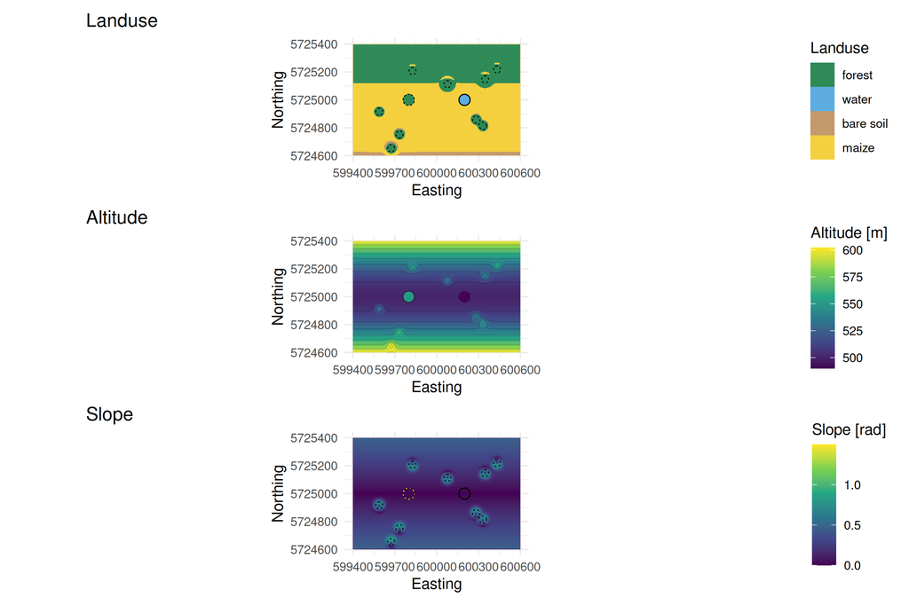

```r
# ========== Landnutzungs- & Gelände-Visualizer ==========
# ------------------------------------------------------------------------------
# plot_landcover_terrain(scen, stations = NULL, show_contours = TRUE)
# Purpose:
#   Visualize land cover, elevation, and slope rasters side-by-side. Optionally
#   overlay station points and draw hill/lake contours for orientation.
# Inputs:
#   - scen: list returned by build_scenario(), must contain E, slp, lc, lake, hillW.
#   - stations: optional sf point layer to overlay.
#   - show_contours: toggle for drawing 0.5 level contours around lake/hill masks.
# Returns:
#   A patchwork-composed ggplot object (no side effects).
# ------------------------------------------------------------------------------
plot_landcover_terrain <- function(scen, stations = NULL, show_contours = TRUE,
                                   layout = c("grid","vertical")) {
  layout <- match.arg(layout)
  stopifnot(all(c("E","slp") %in% names(scen)))

  # Wenn LC fehlt (sollte jetzt nicht passieren), Fall  back bauen
  if (!("lc" %in% names(scen))) {
    E    <- scen$E; slp <- scen$slp
    lake <- if ("lake"  %in% names(scen)) scen$lake  else terra::rast(E)*0
    hill <- if ("hillW" %in% names(scen)) scen$hillW else terra::rast(E)*0
    y0loc <- (terra::ymax(E)+terra::ymin(E))/2
    slp_vals <- terra::values(slp)
    thr_slp  <- stats::quantile(slp_vals[is.finite(slp_vals)], 0.90, na.rm = TRUE)
    lc_fallback <- terra::rast(E); terra::values(lc_fallback) <- 4L  # maize
    lc_fallback <- terra::ifel(lake > 0, 2L, lc_fallback)            # water
    forest_mask <- (hill > 0.2) | (slp > 0.15 & (terra::init(E,"y") > y0loc))
    lc_fallback <- terra::ifel((forest_mask) & (lake <= 0), 1L, lc_fallback)  # forest
    bare_mask <- (slp >= thr_slp) & (lake <= 0) & (!forest_mask)
    lc_fallback <- terra::ifel(bare_mask, 3L, lc_fallback)           # bare soil
    names(lc_fallback) <- "lc"
    scen$lc <- lc_fallback
    lc_levels <- lc_levels_default
    scen$lc_colors <- lc_colors_default
  }

  lc_df  <- as.data.frame(scen$lc,  xy = TRUE); names(lc_df)  <- c("x","y","lc")
  E_df   <- as.data.frame(scen$E,   xy = TRUE); names(E_df)   <- c("x","y","elev")
  slp_df <- as.data.frame(scen$slp, xy = TRUE); names(slp_df) <- c("x","y","slp")

  lc_df$lc <- factor(lc_df$lc, levels = seq_along(lc_levels), labels = lc_levels)
  cols_lc  <- scen$lc_colors

  p_lc <- ggplot() +
    geom_raster(data = lc_df, aes(x, y, fill = lc)) +
    scale_fill_manual(values = cols_lc, na.value = "grey90", name = "Landuse") +
    coord_equal() + theme_minimal() +
    labs(title = "Landuse", x = "Easting", y = "Northing")

  p_elev <- ggplot() +
    geom_raster(data = E_df, aes(x, y, fill = elev)) +
    scale_fill_viridis_c(name = "Altitude [m]") +
    coord_equal() + theme_minimal() +
    labs(title = "Altitude", x = "Easting", y = "Northing")

  p_slp <- ggplot() +
    geom_raster(data = slp_df, aes(x, y, fill = slp)) +
    scale_fill_viridis_c(name = "Slope [rad]") +
    coord_equal() + theme_minimal() +
    labs(title = "Slope", x = "Easting", y = "Northing")

  if (isTRUE(show_contours)) {
    lake_df <- as.data.frame(scen$lake, xy = TRUE); names(lake_df) <- c("x","y","lake")
    hill_df <- as.data.frame(scen$hillW, xy = TRUE); names(hill_df) <- c("x","y","hillW")
    p_elev <- p_elev + geom_contour(data = E_df, aes(x, y, z = elev),
                                    bins = 10, colour = "black", alpha = 0.25,
                                    linewidth = 0.2, inherit.aes = FALSE)
    p_lc  <- p_lc  + geom_contour(data = lake_df, aes(x, y, z = lake),
                                  breaks = 0.5, colour = "black", linewidth = 0.35,
                                  inherit.aes = FALSE) +
                    geom_contour(data = hill_df, aes(x, y, z = hillW),
                                  breaks = 0.5, colour = "black", linetype = "22",
                                  linewidth = 0.3, inherit.aes = FALSE)
    p_slp <- p_slp + geom_contour(data = lake_df, aes(x, y, z = lake),
                                  breaks = 0.5, colour = "black", linewidth = 0.35,
                                  inherit.aes = FALSE) +
                    geom_contour(data = hill_df, aes(x, y, z = hillW),
                                  breaks = 0.5, colour = "black", linetype = "22",
                                  linewidth = 0.3, inherit.aes = FALSE)
  }

  if (!is.null(stations)) {
    add_st <- list(geom_sf(data = stations, colour = "black", fill = "white",
                           shape = 21, size = 1.6, stroke = 0.25, inherit.aes = FALSE))
    p_lc   <- p_lc   + add_st
    p_elev <- p_elev + add_st
    p_slp  <- p_slp  + add_st
  }
  if (layout == "vertical") {
    # stapeln, Legenden behalten
    return(
      (p_lc   + ggplot2::theme(plot.margin = ggplot2::margin(4,4,4,4, unit = "pt"))) /
        (p_elev + ggplot2::theme(plot.margin = ggplot2::margin(4,4,4,4, unit = "pt"))) /
        (p_slp  + ggplot2::theme(plot.margin = ggplot2::margin(4,4,4,4, unit = "pt"))) +
        patchwork::plot_layout(guides = "keep", heights = c(1,1,1))
    )
  } else {
    return((p_lc | (p_elev | p_slp)) + patchwork::plot_layout(guides = "keep"))
  }
}
# ---- Aufruf (direkt nach build_scenario):
plot_landcover_terrain(scen = scen,layout = "vertical")
```

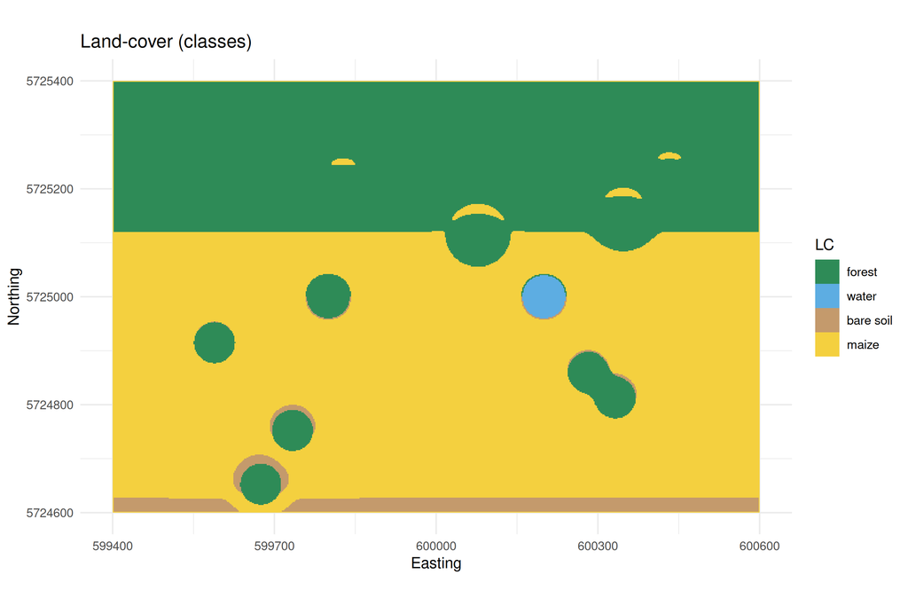

```r
# ---- 2x2 overview panel in English -----------------------------------------
plot_block_overview_2x2_en <- function(scen, pts_sf = NULL) {
  stopifnot(all(c("E","slp","I14","I05") %in% names(scen)))

  # Stack continuous rasters -> data.frame
  Rstack <- c(scen$E, scen$slp, scen$I14, scen$I05)
  df <- terra::as.data.frame(Rstack, xy = TRUE, na.rm = FALSE)
  names(df) <- c("x","y","elev","slope","I14","I05")

  # Base theme & palettes (no extra packages)
  theme_base <- ggplot2::theme_minimal(base_size = 11)
  pal_terrain <- grDevices::hcl.colors(256, "Terrain")
  pal_slope   <- grDevices::hcl.colors(256, "Viridis")
  pal_hot     <- grDevices::hcl.colors(256, "YlOrRd")
  pal_cool    <- grDevices::hcl.colors(256, "PuBuGn")

  p_elev <- ggplot2::ggplot(df, ggplot2::aes(x, y, fill = elev)) +
    ggplot2::geom_raster() + ggplot2::coord_equal() +
    ggplot2::scale_fill_gradientn(colours = pal_terrain, name = "m") +
    ggplot2::labs(title = "Terrain (Elevation)") + theme_base

  p_slope <- ggplot2::ggplot(df, ggplot2::aes(x, y, fill = slope)) +
    ggplot2::geom_raster() + ggplot2::coord_equal() +
    ggplot2::scale_fill_gradientn(colours = pal_slope, name = "rad") +
    ggplot2::labs(title = "Slope (radians)") + theme_base

  p_I14 <- ggplot2::ggplot(df, ggplot2::aes(x, y, fill = I14)) +
    ggplot2::geom_raster() + ggplot2::coord_equal() +
    ggplot2::scale_fill_gradientn(colours = pal_hot, name = "") +
    ggplot2::labs(title = "Insolation 14 UTC (cos i)") + theme_base

  p_I05 <- ggplot2::ggplot(df, ggplot2::aes(x, y, fill = I05)) +
    ggplot2::geom_raster() + ggplot2::coord_equal() +
    ggplot2::scale_fill_gradientn(colours = pal_cool, name = "") +
    ggplot2::labs(title = "Insolation 05 UTC (cos i)") + theme_base

  # Land cover (if available); falls back to slope otherwise
  p_lc <- NULL
  if ("lc" %in% names(scen)) {
    lc_df <- terra::as.data.frame(scen$lc, xy = TRUE, na.rm = FALSE)
    names(lc_df) <- c("x","y","lc")
    lc_levels <- scen$lc_levels %||% scen$lc_lev
    if (!is.null(lc_levels)) {
      lc_df$lc <- factor(lc_df$lc, levels = seq_along(lc_levels), labels = lc_levels)
    }
    lc_cols <- scen$lc_colors %||% c("Forest"="#2E8B57","Water"="#5DADE2",
                                     "Bare soil"="#C49A6C","Maize"="#F4D03F")
    p_lc <- ggplot2::ggplot(lc_df, ggplot2::aes(x, y, fill = lc)) +
      ggplot2::geom_raster() + ggplot2::coord_equal() +
      ggplot2::scale_fill_manual(values = lc_cols, drop = FALSE, name = "Land cover") +
      ggplot2::labs(title = "Land cover") + theme_base
  }

  # Optional station overlay
  if (!is.null(pts_sf)) {
    pts_df <- sf::st_drop_geometry(pts_sf)
    add_pts <- function(p)
      p + ggplot2::geom_point(data = pts_df, ggplot2::aes(x = x, y = y),
                              inherit.aes = FALSE, size = 0.7, alpha = 0.7,
                              colour = "black")
    p_elev  <- add_pts(p_elev)
    p_slope <- add_pts(p_slope)
    p_I14   <- add_pts(p_I14)
    p_I05   <- add_pts(p_I05)
    if (!is.null(p_lc)) p_lc <- add_pts(p_lc)
  }

  # Choose 4th panel: land cover if present, otherwise slope
  p2 <- if (!is.null(p_lc)) p_lc else p_slope

  # 2x2 layout
  # 2x2 layout + rotate x-axis labels 45°
  (p_elev | p2) / (p_I14 | p_I05) +
    patchwork::plot_layout(guides = "collect") &
    ggplot2::theme(
      plot.margin = ggplot2::margin(5,5,5,5),
      axis.text.x = ggplot2::element_text(angle = 45, hjust = 1, vjust = 1)
    )

}




# (Optionale zweite Darstellung – Tippfehler korrigiert)
lc_df <- as.data.frame(scen$lc, xy = TRUE)
names(lc_df) <- c("x","y","lc")
lc_df$lc <- factor(lc_df$lc, levels = 1:length(lc_levels), labels = lc_levels)

ggplot(lc_df, aes(x, y, fill = lc)) +
  geom_raster() +
  scale_fill_manual(values = scen$lc_colors, drop = FALSE) +
  coord_equal() + theme_minimal() +
  labs(title = "Land-cover (classes)", x = "Easting", y = "Northing", fill = "LC")
```

# 5 D. Physics & Scenario Builder — Cheat Sheet (enhanced LC model)

## 5.1 D.1 Generated rasters & derived fields

| Name | Unit | What it is | How it’s built |
| --- | --- | --- | --- |
| `E` (`elev`) | m | Ground elevation | Parabolic “half-pipe” across **y**; + optional hill; − optional pond/hollow |
| `slp`, `asp` | rad | Slope, aspect | `terra::terrain(E, "slope"/"aspect", "radians")` |
| `I14`, `I05` | – | Cosine solar incidence at 14/05 UTC | `cosi_fun(alt, az, slp, asp)`, clamped to `[0,1]` |
| `lc` | cat | Land-cover class | {Forest, Water, Bare Soil, Maize}; rules from hill/slope/water masks |
| `hillW` | 0–1 | Hill weight (1 inside footprint) | Disk/Gaussian on left third; combines main + optional micro-hills |
| `lake` | 0/1 | Water mask | 1 only when `lake_choice == "water"` (disk on right third) |
| `I14_eff` | – | **Shaded** incidence (day) | `I14 * shade_fac_by_lc[lc]` |
| `αI(lc)` | – | Daytime solar sensitivity by LC | Look-up from `alpha_I_by_lc` |
| `dawn_bias(lc)` | °C | Additive pre-dawn bias by LC | Look-up from `dawn_bias_by_lc` |
| `pool_fac(lc)` | – | Pooling multiplier by LC | Look-up from `pool_fac_by_lc` |
| `R14` (`T14`) | °C | Daytime “truth” temperature field | Eq. (below) |
| `R05` (`T05`) | °C | Pre-dawn “truth” temperature field | Eq. (below) |

## 5.2 D.2 Governing equations

$$\texttt{pool\_base} \;=\; A \exp\!\left[-(d_y/w)^2\right],\quad d_y=|y-y_0|,$$

blocked over the hill by `(1 − pool_block_gain * hillW)`.

**Day (14 UTC)**

$$T_{14} \;=\; T0_{14} \;+\; \texttt{lapse\_14}\,(E-\overline{E})
\;+\; \alpha_I(\texttt{lc})\, I_{14}^{\text{eff}}
\;+\; \varepsilon_{14},
\quad
I_{14}^{\text{eff}} = I_{14}\cdot \texttt{shade\_fac}(\texttt{lc}).$$

**Pre-dawn (05 UTC)**

$$T_{05} \;=\; T0_{05} \;+\; \texttt{inv\_05}\,(E-\overline{E})
\;+\; \eta_{\text{slope}}\;\texttt{slp}
\;-\; \texttt{pool\_base}\cdot(1-\texttt{pool\_block\_gain}\cdot\texttt{hillW})\cdot \texttt{pool\_fac}(\texttt{lc})
\;+\; \texttt{dawn\_bias}(\texttt{lc})
\;+\; \varepsilon_{05}.$$

> **Note vs. predecessor:** the former `warm_bias_water_dawn * lake` term is now folded into `dawn_bias(lc)` (class “Water”); daytime `α_map` became `αI(lc) * I14_eff` with explicit canopy shading.

## 5.3 D.3 Dials (what you can tweak)

### 5.3.1 Global scalars

| Parameter | Default | Sensible range | Affects | Visual signature (+) |
| --- | --- | --- | --- | --- |
| `T0_14` | 26.0 °C | 20–35 | T14 baseline | Uniform warming |
| `lapse_14` | −0.0065 °C/m | −0.01…−0.002 | T14 vs elevation | Cooler rims, warmer floor |
| `T0_05` | 8.5 °C | 3–15 | T05 baseline | Uniform warming |
| `inv_05` | +0.003 °C/m | 0–0.008 | T05 vs elevation | Rims warmer vs floor |
| `η_slope` | 0.6 | 0–1.5 | T05 slope flow proxy | Steeper slopes a bit warmer at dawn |
| `pool_base` amplitude | 4.0 K | 1–8 | T05 pooling depth | Stronger blue band on valley axis |
| `w_pool` | 70 m | 40–150 | T05 pooling width | Narrower/broader cold band |
| `pool_block_gain` | 0.4 | 0–1 | Hill blocking | Warm “tongue” over hill at dawn |
| `noise σ` | 0.3 K | 0–1 | Both | Fine speckle/random texture |

### 5.3.2 Land-cover coefficients (by class)

Defaults used in the code:

| LC class | `alpha_I_by_lc` | `shade_fac_by_lc` | `dawn_bias_by_lc` (°C) | `pool_fac_by_lc` |
| --- | --- | --- | --- | --- |
| Forest | 3.5 | 0.6 | +0.3 | 0.7 |
| Water | 1.5 | 1.0 | +1.2 | 0.8 |
| Bare Soil | 6.0 | 1.0 | −0.5 | 1.1 |
| Maize | 4.5 | 0.9 | +0.1 | 1.0 |

**Interpretation:** *Bare Soil* heats most by day and **enhances pooling** (factor > 1) and cool bias at dawn; *Forest* damps radiation by day (shading) and **reduces pooling** (factor < 1); *Water* heats little by day, gets a **positive dawn bias** and reduced pooling; *Maize* sits between grass and forest.

### 5.3.3 Geometry/toggles

[output not shown]

## 5.4 D.4 Quick “recipes”

- **Cloud/haze day** → ↓ `alpha_I_by_lc` (all classes, esp. Bare/Maize) → daytime LC contrasts fade; models lean on elevation/smoothness.
- **Hotter afternoon** → ↑ `T0_14` (+1…+3 K) → uniform bias shift; rankings unchanged.
- **Stronger pooling** → ↑ `pool_base` and/or ↓ `w_pool` → sharper, deeper trough; drift-aware models gain.
- **Water vs hollow** → `"water"` sets LC=Water → ↓ daytime heating, ↑ dawn warm bias, ↓ pooling; `"hollow"` keeps only geometry (no water thermals).
- **Hill blocking** → ↑ `pool_block_gain` → warm dawn tongue over hill; harder CV across blocks.
- **Cover swaps** (what if): set a patch to *Bare Soil* → warmer day, **colder dawn & stronger pooling**; to *Forest* → cooler day, **weaker pooling & slight dawn warm-up**.

## 5.6 D.6 What each term *looks like* on maps

| Term | Map signature |
| --- | --- |
| `lapse_14 * (E-Ȇ)` | Subtle cool rims / warm floor (day) |
| `αI(lc) * I14_eff` | Warm sun-facing slopes; **damped under forest/water** |
| `inv_05 * (E-Ȇ)` | Rims warmer vs pooled floor (dawn inversion) |
| `η_slope * slp` | Slight dawn warm bias on steeper slopes |
| `− pool_base * (1−gain*hillW) * pool_fac(lc)` | Blue band on axis; **weaker over forest/water**, **stronger bare** |
| `+ dawn_bias(lc)` | Local dawn warm spots (water/forest), cool bias (bare) |

## 5.7 D.8 Settings of the current example

> `alpha_I_by_lc = c(Forest=3.5, Water=1.5, Bare=6.0, Maize=4.5)`, `shade_fac_by_lc = c(0.6,1.0,1.0,0.9)`, `dawn_bias_by_lc = c(+0.3,+1.2,−0.5,+0.1)`, `pool_fac_by_lc = c(0.7,0.8,1.1,1.0)`.

# 6 E. Stations: sampling & extraction

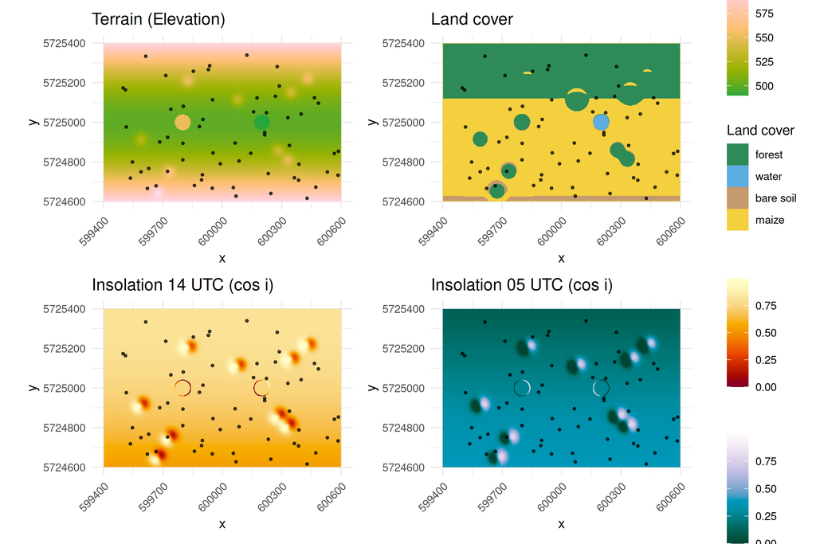

```r
# Station coordinates ---------------------------------------------------
if (station_mode == "random") {
  pts <- tibble::tibble(
    id = 1:n_st,
    x  = runif(n_st, xmin + transect_margin_m, xmax - transect_margin_m),
    y  = runif(n_st, ymin + transect_margin_m, ymax - transect_margin_m)
  )
} else if (station_mode == "ns_transect") {
  x_const <- min(max(x0 + ns_offset_m, xmin + transect_margin_m), xmax - transect_margin_m)
  y_seq   <- seq(ymin + transect_margin_m, ymax - transect_margin_m, length.out = n_st)
  pts <- tibble::tibble(id = 1:n_st, x = x_const, y = y_seq)
} else if (station_mode == "ew_transect") {
  y_const <- min(max(y0 + ew_offset_m, ymin + transect_margin_m), ymax - transect_margin_m)
  x_seq   <- seq(xmin + transect_margin_m, xmax - transect_margin_m, length.out = n_st)
  pts <- tibble::tibble(id = 1:n_st, x = x_seq, y = y_const)
} else stop("Unknown station_mode")

pts_sf <- sf::st_as_sf(pts, coords = c("x","y"), crs = crs_utm, remove = FALSE)
vpts   <- terra::vect(pts_sf)

# Extract covariates & targets -----------------------------------------
pts$z_surf <- as.numeric(terra::extract(scen$E,   vpts, ID = FALSE)[,1])
pts$slp    <- as.numeric(terra::extract(scen$slp, vpts, ID = FALSE)[,1])
pts$I14    <- as.numeric(terra::extract(scen$I14, vpts, ID = FALSE)[,1])
pts$I05    <- as.numeric(terra::extract(scen$I05, vpts, ID = FALSE)[,1])
pts$lc     <- as.integer(terra::extract(scen$lc,  vpts, ID = FALSE)[,1])
pts$T14    <- as.numeric(terra::extract(scen$R14, vpts, ID = FALSE)[,1])
pts$T05    <- as.numeric(terra::extract(scen$R05, vpts, ID = FALSE)[,1])

# Keep complete rows per time slot -------------------------------------
pts14 <- pts[stats::complete.cases(pts[, c("x","y","z_surf","slp","I14","lc","T14")]), ]
pts05 <- pts[stats::complete.cases(pts[, c("x","y","z_surf","slp","I05","lc","T05")]), ]

# Unify response name to 'temp' and carry LC as factor -----------------
# Unify response 'temp' and carry LC as factor with global levels ---------------
stn_sf_14 <- pts14 |>
  dplyr::transmute(
    id, x, y,
    z_surf = as.numeric(z_surf),
    slp    = as.numeric(slp),
    cosi   = as.numeric(I14),
    lc     = factor(lc_levels[pmax(1, pmin(lc, length(lc_levels)))], levels = lc_levels),
    temp   = as.numeric(T14)
  ) |>
  sf::st_as_sf(coords = c("x","y"), crs = crs_utm, remove = FALSE)

stn_sf_05 <- pts05 |>
  dplyr::transmute(
    id, x, y,
    z_surf = as.numeric(z_surf),
    slp    = as.numeric(slp),
    cosi   = as.numeric(I05),
    lc     = factor(lc_levels[pmax(1, pmin(lc, length(lc_levels)))], levels = lc_levels),
    temp   = as.numeric(T05)
  ) |>
  sf::st_as_sf(coords = c("x","y"), crs = crs_utm, remove = FALSE)

# With station overlay (e.g., T14)
plot_block_overview_2x2_en(scen, pts_sf = stn_sf_14)
```

# 7 E. Modeling helpers (blocks, learners, CV)

```r
#| label: lbo-helpers
#| echo: false
#| message: false
#| warning: false
#| results: 'asis'

# — Compute metrics from a CV table (fallback) —
lbo_compute_metrics <- function(cv_tbl) {
  stopifnot(all(c("model","obs","pred") %in% names(cv_tbl)))
  dplyr::group_by(cv_tbl, model) |>
    dplyr::summarise(
      n    = dplyr::n(),
      n_ok = sum(is.finite(obs) & is.finite(pred)),
      MAE  = mean(abs(pred - obs), na.rm = TRUE),
      RMSE = sqrt(mean((pred - obs)^2, na.rm = TRUE)),
      Bias = mean(pred - obs, na.rm = TRUE),
      R2   = {
        m <- mean(obs, na.rm=TRUE)
        1 - sum((pred-obs)^2, na.rm=TRUE) / sum((obs-m)^2, na.rm=TRUE)
      },
      .groups = "drop"
    ) |>
    dplyr::arrange(RMSE)
}

# — Show metrics from df or file —
lbo_show_metrics <- function(metrics_df = NULL, csv = NULL, html = NULL, caption = "LBO-CV metrics — baseline") {
  if (!is.null(metrics_df)) {
    return(knitr::kable(metrics_df, format="html", digits=3, caption = caption))
  }
  if (!is.null(html) && file.exists(html)) {
    return(htmltools::includeHTML(html))
  }
  if (!is.null(csv) && file.exists(csv)) {
    df <- read.csv(csv, check.names = FALSE)
    return(knitr::kable(df, format="html", digits=3, caption = caption))
  }
  cat("<em>metrics not found</em>")
}

# — Print a “panel” object robustly (patchwork or list-of-pages) —
lbo_print_panel <- function(panel_obj = NULL, page = 1, panel_png = NULL) {
  if (!is.null(panel_obj)) {
    # panel kann patchwork sein ODER Liste von Seiten (z.B. $pages)
    if (is.list(panel_obj) && !is.null(panel_obj$pages)) {
      print(panel_obj$pages[[page]])
      return(invisible(TRUE))
    }
    if (is.list(panel_obj) && all(vapply(panel_obj, inherits, logical(1), what="gg"))) {
      print(panel_obj[[page]])
      return(invisible(TRUE))
    }
    print(panel_obj)
    return(invisible(TRUE))
  }
  if (!is.null(panel_png) && file.exists(panel_png)) {
    cat(sprintf("![](%s){width=100%%}\n", panel_png))
    return(invisible(TRUE))
  }
  cat("<em>panel not available</em>\n")
  invisible(FALSE)
}



# ===================== SF-ONLY GEOSTATS PATCH =====================

# ---- Helpers ------------------------------------------------------
.align_factor_pair <- function(train_x, grid_x, fallback = NULL) {
  tl <- unique(na.omit(as.character(train_x)))
  if (!length(tl)) return(list(use = FALSE, train = NULL, grid = NULL, levels = character()))
  lev <- if (is.null(fallback)) tl else unique(c(tl, fallback))
  trc <- factor(as.character(train_x), levels = lev)
  gdc <- factor(as.character(grid_x),  levels = lev)
  list(use = TRUE, train = trc, grid = gdc, levels = lev)
}
.align_factor_to_model <- function(x, lev_model) {
  y <- factor(as.character(x), levels = lev_model)
  if (anyNA(y)) y[is.na(y)] <- lev_model[1]
  y
}
.fill_num_na_vec <- function(x, ref) {
  m <- stats::median(ref[is.finite(ref)], na.rm = TRUE)
  x[!is.finite(x)] <- m
  x
}
.default_vgm <- function(values, model = "Exp", range = 100) {
  psill <- stats::var(values, na.rm = TRUE); nug <- 0.1 * psill
  gstat::vgm(psill = psill, model = model, range = range, nugget = nug)
}

# ---- SF Learner: Voronoi / Next Neighbour -------------------------
pred_Voronoi <- function(train_sf, test_sf) {
  idx <- sf::st_nearest_feature(test_sf, train_sf)
  as.numeric(train_sf$temp)[idx]
}

# ---- SF Learner: IDW ----------------------------------------------
pred_IDW <- function(train_sf, test_sf, idp = 2) {
  # train_sf: sf POINTS mit Spalte 'temp'
  # test_sf : sf POINTS, beliebige Zusatzspalten
  pr <- suppressWarnings(gstat::idw(temp ~ 1, locations = train_sf, newdata = test_sf, idp = idp))
  as.numeric(pr$var1.pred)
}

# ---- SF Learner: Ordinary Kriging ---------------------------------
pred_OK <- function(train_sf, test_sf) {
  vg      <- suppressWarnings(gstat::variogram(temp ~ 1, data = train_sf))
  vgm_fit <- try(suppressWarnings(gstat::fit.variogram(vg, gstat::vgm("Exp"))), silent = TRUE)
  if (inherits(vgm_fit, "try-error")) vgm_fit <- .default_vgm(train_sf$temp)
  pr <- suppressWarnings(gstat::krige(temp ~ 1, locations = train_sf, newdata = test_sf, model = vgm_fit))
  as.numeric(pr$var1.pred)
}

# ---- SF Learner: KED (UK mit externen Drifts) ---------------------
# --- sf-only KED (schluckt extra Args wie E=E) ----------------------
pred_KED <- function(train_sf, test_sf, ...) {
  stopifnot(inherits(train_sf, "sf"), inherits(test_sf, "sf"))
  need <- c("z_surf","slp","cosi")
  miss <- setdiff(need, names(train_sf))
  if (length(miss)) stop("pred_KED(): fehlende Drift-Spalten im Training: ",
                         paste(miss, collapse = ", "))

  # Optional LC als Faktor angleichen
  use_lc <- "lc" %in% names(train_sf) && "lc" %in% names(test_sf)
  tr <- train_sf
  te <- test_sf
  if (use_lc) {
    tr$lc <- droplevels(factor(tr$lc))
    te$lc <- factor(as.character(te$lc), levels = levels(tr$lc))
    te$lc[is.na(te$lc)] <- levels(tr$lc)[1]
  }

  # fehlende numerische Drifts im TEST mit Trainingsmedian auffüllen
  for (nm in need) {
    m <- stats::median(tr[[nm]][is.finite(tr[[nm]])], na.rm = TRUE)
    te[[nm]][!is.finite(te[[nm]])] <- m
  }

  # nur vollständige Trainingszeilen
  keep_tr <- c("temp", need, if (use_lc) "lc")
  dtr <- sf::st_drop_geometry(tr)[, keep_tr, drop = FALSE]
  ok  <- stats::complete.cases(dtr)
  tr  <- tr[ok, ]
  if (nrow(tr) < 5) return(rep(NA_real_, nrow(te)))

  # Formel: lineare Drifts + optional LC
  form <- stats::as.formula(paste("temp ~", paste(c(need, if (use_lc) "lc"), collapse = " + ")))

  # Variogramm + robuster Fit
  vg      <- suppressWarnings(gstat::variogram(form, data = tr))
  vgm_fit <- try(suppressWarnings(gstat::fit.variogram(vg, gstat::vgm("Exp"))), silent = TRUE)
  if (inherits(vgm_fit, "try-error")) {
    ps <- stats::var(sf::st_drop_geometry(tr)$temp, na.rm = TRUE)
    vgm_fit <- gstat::vgm(psill = ps, model = "Exp", range = max(vg$dist, na.rm = TRUE)/3, nugget = 0.1*ps)
  }

  # Kriging mit externen Drifts (UK/KED)
  pr <- suppressWarnings(gstat::krige(form, locations = tr, newdata = te, model = vgm_fit))
  as.numeric(pr$var1.pred)
}
```

```r
pred_RF <- function(train_sf, test_sf) {
  dtr <- sf::st_drop_geometry(train_sf)
  if (!("lc" %in% names(dtr))) dtr$lc <- factor("Wald", levels = lc_levels)
  dtr$lc <- droplevels(factor(as.character(dtr$lc), levels = lc_levels))
  dtr <- stats::na.omit(dtr)
  if (nrow(dtr) < 5) return(rep(NA_real_, nrow(test_sf)))
  rf  <- randomForest::randomForest(temp ~ x + y + z_surf + slp + cosi + lc, data = dtr, na.action = na.omit)

  dte <- sf::st_drop_geometry(test_sf)
  if (!("lc" %in% names(dte))) dte$lc <- factor("Wald", levels = lc_levels)
  lev <- levels(dtr$lc)
  dte$lc <- .align_factor_to_model(dte$lc, lev)

  good <- stats::complete.cases(dte[, c("x","y","z_surf","slp","cosi","lc")])
  out  <- rep(NA_real_, nrow(dte)); if (any(good)) out[good] <- stats::predict(rf, dte[good, ])
  out
}

# GAM-Fitter (nutzt safe_gam_formula)
fit_gam_safe <- function(stn_sf) {
  d <- stn_sf |> sf::st_drop_geometry()
  d <- d[stats::complete.cases(d[, c("x","y","temp","z_surf","slp","cosi")]), , drop = FALSE]
  if (nrow(d) < 10) stop("Too few stations for GAM: n=", nrow(d))
  mgcv::gam(formula = safe_gam_formula(d), data = d, method = "REML", select = TRUE)
}

pred_GAM <- function(train_sf, test_sf) {
  # training data (keep only columns we’ll use, drop NAs)
  dtr  <- sf::st_drop_geometry(train_sf)
  keep <- intersect(c("temp","x","y","z_surf","slp","cosi","lc"), names(dtr))
  dtr  <- dtr[stats::complete.cases(dtr[, keep, drop = FALSE]), keep, drop = FALSE]
  if (!nrow(dtr)) return(rep(NA_real_, nrow(test_sf)))

  # land cover: optionally include as factor main effect
  if ("lc" %in% names(dtr)) dtr$lc <- droplevels(factor(dtr$lc))
  inc_lc <- "lc" %in% names(dtr) && nlevels(dtr$lc) >= 2

  # fit GAM with guarded formula (dynamic k, optional terms)
  if (nrow(dtr) < 10) return(rep(NA_real_, nrow(test_sf)))
  gm <- mgcv::gam(
    formula = safe_gam_formula(dtr, include_lc = inc_lc),
    data    = dtr,
    method  = "REML",
    select  = TRUE
  )

  # prediction data (+ align LC levels to model, if used)
  dte <- sf::st_drop_geometry(test_sf)
  vars <- c("x","y","z_surf","slp","cosi", if (inc_lc) "lc")
  vars <- intersect(vars, names(dte))

  if (inc_lc) {
    # align factor levels; assumes you have .align_factor_to_model()
    lev <- levels(model.frame(gm)$lc)
    if (!("lc" %in% names(dte))) dte$lc <- lev[1]
    dte$lc <- .align_factor_to_model(dte$lc, lev)
  }

  good <- stats::complete.cases(dte[, vars, drop = FALSE])
  out  <- rep(NA_real_, nrow(dte))
  if (any(good)) {
    out[good] <- stats::predict(gm, dte[good, vars, drop = FALSE], type = "response")
  }
  out
}



# ---- SF-only predict_maps (kein sp, kein grid_sp) -------------------
# ---------- SF-only predict_maps ----------
predict_maps <- function(stn_sf, truth_raster,
                         which_time = c("T14","T05"),
                         scen, models = c("Voronoi","IDW","OK","KED","RF","GAM"),
                         lc_levels = NULL,
                         feature_rasters = NULL) {
  which_time <- match.arg(which_time)
  lc_levels  <- lc_levels %||% scen$lc_levels

  # Basis-/Feature-Raster setzen
  E      <- scen$E
  slp_r  <- scen$slp
  cosi_r <- if (which_time == "T14") scen$I14 else scen$I05
  if (!is.null(feature_rasters)) {
    if (!is.null(feature_rasters$E))     E     <- feature_rasters$E
    if (!is.null(feature_rasters$slp))   slp_r <- feature_rasters$slp
    if (!is.null(feature_rasters$cosi))  cosi_r<- feature_rasters$cosi
  }
  has_lc <- ("lc" %in% names(scen)) && !is.null(scen$lc)
  lc_r   <- if (has_lc) scen$lc else NULL

  # Trainingsdaten vervollständigen
  train_sf <- stn_sf
  if (!all(c("x","y") %in% names(train_sf))) {
    xy <- sf::st_coordinates(train_sf); train_sf$x <- xy[,1]; train_sf$y <- xy[,2]
  }
  if (!("z_surf" %in% names(train_sf)))
    train_sf$z_surf <- as.numeric(terra::extract(E,      sf::st_coordinates(train_sf))[,1])
  if (!("slp" %in% names(train_sf)))
    train_sf$slp    <- as.numeric(terra::extract(slp_r,  sf::st_coordinates(train_sf))[,1])
  if (!("cosi" %in% names(train_sf)))
    train_sf$cosi   <- as.numeric(terra::extract(cosi_r, sf::st_coordinates(train_sf))[,1])
  if (has_lc && !("lc" %in% names(train_sf))) {
    lc_codes <- as.integer(terra::extract(lc_r, sf::st_coordinates(train_sf))[,1])
    lc_codes[is.na(lc_codes)] <- 1L
    lc_codes <- pmax(1L, pmin(lc_codes, length(lc_levels)))
    train_sf$lc <- factor(lc_levels[lc_codes], levels = lc_levels)
  }

  # Vorhersage-Grid 1:1 zu Rasterzellen (nie filtern)
  xy <- as.data.frame(terra::xyFromCell(E, 1:terra::ncell(E))); names(xy) <- c("x","y")
  grid_df <- xy
  grid_df$z_surf <- as.numeric(terra::values(E))
  grid_df$slp    <- as.numeric(terra::values(slp_r))
  grid_df$cosi   <- as.numeric(terra::values(cosi_r))
  if (has_lc) {
    lc_codes <- as.integer(terra::values(lc_r))
    lc_codes[!is.finite(lc_codes)] <- 1L
    lc_codes <- pmax(1L, pmin(lc_codes, length(lc_levels)))
    grid_df$lc <- factor(lc_levels[lc_codes], levels = lc_levels)
  }
  grid_sf <- sf::st_as_sf(grid_df, coords = c("x","y"),
                          crs = sf::st_crs(train_sf), remove = FALSE)

  # LC-Levels train/grid angleichen (hart, ohne __OTHER__)
  use_lc <- has_lc && ("lc" %in% names(train_sf)) && ("lc" %in% names(grid_sf))
  if (use_lc) {
    lev <- levels(droplevels(factor(train_sf$lc)))
    train_sf$lc <- factor(as.character(train_sf$lc), levels = lev)
    grid_sf$lc  <- factor(as.character(grid_sf$lc),  levels = lev)
    if (anyNA(train_sf$lc) || anyNA(grid_sf$lc)) {
      use_lc <- FALSE; train_sf$lc <- NULL; grid_sf$lc <- NULL
    }
  }

  # Modelle laufen lassen
  pred_list <- list()
  if ("Voronoi" %in% models) pred_list$Voronoi <- pred_Voronoi(train_sf, grid_sf)
  if ("IDW"     %in% models) pred_list$IDW     <- pred_IDW    (train_sf, grid_sf, idp = 2)
  if ("OK"      %in% models) pred_list$OK      <- pred_OK     (train_sf, grid_sf)
  if ("KED"     %in% models) pred_list$KED     <- pred_KED    (train_sf, grid_sf)

  if ("RF" %in% models) {
    dtr <- sf::st_drop_geometry(train_sf)
    rf_vars <- c("x","y","z_surf","slp","cosi", if (use_lc) "lc")
    dtr <- stats::na.omit(dtr[, c("temp", rf_vars), drop = FALSE])
    pred_list$RF <- if (nrow(dtr) >= 5) {
      rf <- randomForest::randomForest(
        stats::as.formula(paste("temp ~", paste(rf_vars, collapse = " + "))),
        data = dtr, na.action = na.omit
      )
      as.numeric(stats::predict(rf, sf::st_drop_geometry(grid_sf)[, rf_vars, drop = FALSE]))
    } else rep(NA_real_, nrow(grid_sf))
  }
```

```r
  if ("GAM" %in% models) {
    dtr <- sf::st_drop_geometry(train_sf)
    keep <- c("temp","x","y","z_surf","slp","cosi", if (use_lc) "lc")
    dtr  <- dtr[stats::complete.cases(dtr[, keep, drop = FALSE]), keep, drop = FALSE]
    if (nrow(dtr) >= 10) {
      form <- safe_gam_formula(dtr, include_lc = use_lc)
      gm   <- mgcv::gam(form, data = dtr, method = "REML", select = TRUE)
      vars_needed <- setdiff(all.vars(formula(gm)), "temp")
      nd <- sf::st_drop_geometry(grid_sf)[, vars_needed, drop = FALSE]
      mf <- try(model.frame(gm), silent = TRUE)
      if (!inherits(mf, "try-error")) {
        for (vn in vars_needed) if (is.factor(mf[[vn]])) {
          nd[[vn]] <- factor(as.character(nd[[vn]]), levels = levels(mf[[vn]]))
          na_idx <- is.na(nd[[vn]]); if (any(na_idx)) nd[[vn]][na_idx] <- levels(mf[[vn]])[1L]
        }
      }
      good <- stats::complete.cases(nd)
      tmp  <- rep(NA_real_, nrow(grid_sf))
      if (any(good)) tmp[good] <- stats::predict(gm, nd[good, , drop = FALSE], type = "response")
      pred_list$GAM <- tmp
    } else pred_list$GAM <- rep(NA_real_, nrow(grid_sf))
  }

  # Ausgaben
  pred_df <- dplyr::bind_rows(lapply(names(pred_list), function(nm) {
    tibble::tibble(model = nm, x = grid_df$x, y = grid_df$y, pred = pred_list[[nm]])
  }))

  make_r <- function(vals, template = E) {
    stopifnot(length(vals) == terra::ncell(template))
    r <- terra::rast(template); terra::values(r) <- as.numeric(vals); r
  }
  pred_rasters <- lapply(pred_list, make_r)

  truth_df <- as.data.frame(truth_raster, xy = TRUE, na.rm = FALSE)
  names(truth_df) <- c("x","y","truth")
  lims <- stats::quantile(truth_df$truth, probs = stretch_q, na.rm = TRUE)

  p_pred <- ggplot2::ggplot(pred_df, ggplot2::aes(x, y, fill = pred)) +
    ggplot2::geom_raster() +
    ggplot2::scale_fill_gradientn(colors = temp_palette, limits = lims,
                                  oob = scales::squish, name = "Temp") +
    ggplot2::coord_equal() + ggplot2::theme_minimal() +
    ggplot2::labs(title = sprintf("%s — Predictions by model", which_time),
                  x = "Easting", y = "Northing") +
    ggplot2::facet_wrap(~ model, ncol = 3)

  p_truth <- ggplot2::ggplot(truth_df, ggplot2::aes(x, y, fill = truth)) +
    ggplot2::geom_raster() +
    ggplot2::scale_fill_gradientn(colors = temp_palette, limits = lims,
                                  oob = scales::squish, name = "Temp") +
    ggplot2::coord_equal() + ggplot2::theme_minimal() +
    ggplot2::labs(title = sprintf("%s — Truth raster", which_time),
                  x = "Easting", y = "Northing")

  list(
    pred_df      = pred_df,
    pred_rasters = pred_rasters,
    p_pred       = p_pred,
    p_truth      = p_truth
  )
}


# ===================== Ende SF-Patch =====================



# Quick station table ---------------------------------------------------
pts |> dplyr::transmute(
  id, easting = round(x), northing = round(y),
  z_surf = round(z_surf,1), LC = lc_levels[lc],
  T14_C = round(T14,1), T05_C = round(T05,1)
) |> knitr::kable(caption = "Station sample (sanity check)", digits = 1)
```

Station sample (sanity check)

| id | easting | northing | z_surf | LC | T14_C | T05_C |
| --- | --- | --- | --- | --- | --- | --- |
| 1 | 600158 | 5725053 | 501.8 | maize | 28.9 | 6.7 |
| 2 | 600124 | 5725339 | 571.8 | forest | 27.3 | 9.4 |
| 3 | 600223 | 5725049 | 501.5 | maize | 29.6 | 5.9 |
| 4 | 599714 | 5725236 | 535.1 | forest | 27.9 | 8.5 |
| 5 | 599499 | 5725173 | 518.7 | forest | 28.1 | 8.9 |
| 6 | 599801 | 5724894 | 507.2 | maize | 28.7 | 8.2 |
| 7 | 600055 | 5724671 | 567.7 | maize | 27.8 | 9.0 |
| 8 | 599936 | 5725286 | 550.8 | forest | 27.8 | 9.0 |
| 9 | 599803 | 5725081 | 504.1 | maize | 29.3 | 7.5 |
| 10 | 600364 | 5724720 | 549.4 | maize | 28.9 | 9.1 |
| 11 | 600245 | 5724641 | 580.6 | maize | 27.5 | 9.2 |
| 12 | 600175 | 5725123 | 509.5 | forest | 27.6 | 8.3 |
| 13 | 600064 | 5724895 | 506.9 | maize | 28.8 | 8.0 |
| 14 | 599511 | 5725163 | 516.6 | forest | 27.6 | 8.5 |
| 15 | 599949 | 5724667 | 569.3 | maize | 28.6 | 9.1 |
| 16 | 599990 | 5724791 | 527.3 | maize | 28.7 | 8.6 |
| 17 | 600385 | 5724707 | 553.7 | maize | 28.1 | 9.1 |
| 18 | 600472 | 5724673 | 566.8 | maize | 27.8 | 8.7 |
| 19 | 600387 | 5724788 | 528.3 | maize | 28.0 | 8.6 |
| 20 | 599546 | 5724799 | 525.3 | maize | 28.6 | 8.6 |
| 21 | 600398 | 5725042 | 501.2 | maize | 29.7 | 5.8 |
| 22 | 599515 | 5724976 | 500.3 | maize | 29.4 | 4.7 |
| 23 | 600084 | 5724805 | 523.8 | maize | 28.9 | 8.9 |
| 24 | 599613 | 5725333 | 569.3 | forest | 27.5 | 9.5 |
| 25 | 600144 | 5724844 | 515.4 | maize | 29.2 | 8.5 |
| 26 | 600465 | 5725124 | 509.8 | forest | 27.7 | 8.4 |
| 27 | 600069 | 5724627 | 587.0 | bare soil | 29.1 | 8.4 |
| 28 | 599895 | 5724709 | 552.9 | maize | 28.5 | 8.9 |
| 29 | 600566 | 5724843 | 515.4 | maize | 28.6 | 8.8 |
| 30 | 600288 | 5725183 | 521.0 | forest | 28.2 | 8.6 |
| 31 | 599902 | 5725014 | 500.1 | maize | 29.1 | 4.8 |
| 32 | 599899 | 5724735 | 543.9 | maize | 28.4 | 8.7 |
| 33 | 600485 | 5725096 | 505.9 | maize | 29.5 | 8.3 |
| 34 | 600232 | 5724741 | 541.9 | maize | 28.2 | 8.9 |
| 35 | 599628 | 5724767 | 533.9 | maize | 28.3 | 9.2 |
| 36 | 599930 | 5725266 | 544.6 | forest | 27.8 | 9.2 |
| 37 | 600428 | 5724616 | 591.7 | bare soil | 28.7 | 7.9 |
| 38 | 599953 | 5724846 | 515.0 | maize | 28.8 | 8.7 |
| 39 | 600586 | 5724854 | 513.5 | maize | 28.4 | 8.6 |
| 40 | 599859 | 5724681 | 563.6 | maize | 28.5 | 9.1 |
| 41 | 599724 | 5724924 | 503.5 | maize | 29.7 | 7.4 |
| 42 | 600331 | 5725024 | 500.3 | maize | 29.1 | 5.1 |
| 43 | 599854 | 5725258 | 542.0 | forest | 27.5 | 8.9 |
| 44 | 600584 | 5724733 | 544.6 | maize | 28.6 | 8.9 |
| 45 | 599536 | 5724718 | 549.4 | maize | 28.3 | 8.9 |
| 46 | 600214 | 5724949 | 501.6 | maize | 28.8 | 5.8 |
| 47 | 599950 | 5725114 | 508.0 | maize | 29.3 | 8.5 |
| 48 | 599621 | 5724666 | 570.1 | maize | 28.4 | 9.0 |
| 49 | 599666 | 5724679 | 574.8 | forest | 26.2 | 9.2 |
| 50 | 599740 | 5725066 | 502.8 | maize | 28.8 | 7.2 |
| 51 | 600268 | 5725131 | 510.7 | forest | 27.9 | 9.0 |
| 52 | 599589 | 5724750 | 539.4 | maize | 28.4 | 9.0 |
| 53 | 600530 | 5724749 | 539.4 | maize | 28.4 | 8.8 |
| 54 | 599723 | 5724752 | 560.2 | forest | 27.2 | 8.5 |
| 55 | 599884 | 5724978 | 500.3 | maize | 28.9 | 5.1 |
| 56 | 600339 | 5724883 | 509.0 | maize | 28.8 | 8.9 |
| 57 | 599800 | 5724810 | 522.3 | maize | 29.4 | 9.1 |
| 58 | 600277 | 5725281 | 549.4 | forest | 27.5 | 9.0 |
| 59 | 599684 | 5724901 | 506.1 | maize | 29.4 | 7.7 |
| 60 | 600214 | 5724936 | 502.5 | maize | 29.6 | 6.7 |

```r
assemble_simple_panel <- function(maps, cv_tbl, which_time = c("T14","T05")) {
  which_time <- match.arg(which_time)

  # Modelle in EINER Reihe
  p_models_row <- maps$p_pred +
    ggplot2::facet_wrap(~model, nrow = 1) +
    #ggplot2::labs(title = sprintf("%s — Predictions by model", which_time))

  # Eine Truth-Karte
  p_truth <- maps$p_truth + ggplot2::labs(title = sprintf("%s — truth", which_time))
  #
  # Fehler-Panels
  p_block <- make_block_metric_box(cv_tbl, which_time)
  p_abs   <- make_abs_error_box(cv_tbl, which_time)
  p_dens  <- make_residual_density(cv_tbl, which_time)

  # Layout
  (      p_truth /
      p_models_row /
       p_block/
        p_abs /
      p_dens
  ) + patchwork::plot_layout(heights = c(1.1, 0.9, 1, 0.8))
}
#----------


# sorgt dafür, dass X_tr und X_te exakt die gleichen Spaltennamen/Anzahl haben
.reconcile_mm_cols <- function(X_tr, X_te) {
  miss_te <- setdiff(colnames(X_tr), colnames(X_te))
  if (length(miss_te)) {
    X_te <- cbind(
      X_te,
      matrix(0, nrow = nrow(X_te), ncol = length(miss_te),
             dimnames = list(NULL, miss_te))
    )
  }
  miss_tr <- setdiff(colnames(X_te), colnames(X_tr))
  if (length(miss_tr)) {
    X_tr <- cbind(
      X_tr,
      matrix(0, nrow = nrow(X_tr), ncol = length(miss_tr),
             dimnames = list(NULL, miss_tr))
    )
  }
  # identische Spaltenreihenfolge
  X_te <- X_te[, colnames(X_tr), drop = FALSE]
  list(X_tr = X_tr, X_te = X_te)
}

safe_r2 <- function(obs, pred) {
  idx <- is.finite(obs) & is.finite(pred)
  if (sum(idx) < 2) return(NA_real_)
  x <- obs[idx]; y <- pred[idx]
  sx <- stats::sd(x); sy <- stats::sd(y)
  if (!is.finite(sx) || !is.finite(sy) || sx == 0 || sy == 0) return(NA_real_)
  stats::cor(x, y)^2
}

.k_for_xy <- function(n, n_xy) max(3, min(60, n_xy - 1L, floor(n * 0.8)))
.kcap_unique <- function(x, kmax) {
  ux <- unique(x[is.finite(x)])
  nu <- length(ux)
  if (nu <= 3) return(0L)                # treat as constant/near-constant
  max(4L, min(kmax, nu - 1L))
}

# Error/diagnostic panels ----------------------------------------------
block_metrics_long <- function(cv_tbl) {
  stopifnot(all(c("model","block_id","obs","pred") %in% names(cv_tbl)))
  cv_tbl |>
    dplyr::group_by(model, block_id) |>
    dplyr::summarise(RMSE = sqrt(mean((obs - pred)^2, na.rm = TRUE)), MAE = mean(abs(obs - pred), na.rm = TRUE), .groups = "drop") |>
    tidyr::pivot_longer(c(RMSE, MAE), names_to = "Metric", values_to = "Value")
}

order_models_by_median_rmse <- function(cv_tbl) {
  bm <- block_metrics_long(cv_tbl)
  bm |>
    dplyr::filter(Metric == "RMSE") |>
    dplyr::group_by(model) |>
    dplyr::summarise(med = stats::median(Value, na.rm = TRUE), .groups = "drop") |>
    dplyr::arrange(med) |>
    dplyr::pull(model)
}

make_block_metric_box <- function(cv_tbl, which_time = "T14", tail_cap = 0.995) {
  bm <- block_metrics_long(cv_tbl) |>
    dplyr::filter(is.finite(Value))
  if (!is.null(tail_cap)) {
    ymax <- stats::quantile(bm$Value, tail_cap, na.rm = TRUE)
  }
  lev <- order_models_by_median_rmse(cv_tbl)
  bm$model <- factor(bm$model, levels = lev)

  ggplot2::ggplot(bm, ggplot2::aes(model, Value)) +
    ggplot2::geom_boxplot(outlier.alpha = 0.35, width = 0.7) +
    ggplot2::stat_summary(fun = mean, geom = "point", shape = 23, size = 3,
                          fill = "white", colour = "black", stroke = 0.5) +
    ggplot2::coord_cartesian(ylim = c(0, ymax)) +
    ggplot2::theme_minimal() +
    ggplot2::labs(title = sprintf("%s — Block-wise errors (LBO-CV)", which_time),
                  subtitle = "Box = IQR · line = median · ◆ = mean",
                  x = "Model", y = "Error") +
    ggplot2::facet_wrap(~ Metric, scales = "free_y")
}

make_abs_error_box <- function(cv_tbl, which_time = "T14", tail_cap = 0.995) {
  df <- cv_tbl |>
    dplyr::mutate(abs_err = abs(pred - obs)) |>
    dplyr::filter(is.finite(abs_err))
  ymax <- if (!is.null(tail_cap)) stats::quantile(df$abs_err, tail_cap, na.rm = TRUE) else max(df$abs_err, na.rm = TRUE)
  lev <- df |>
    dplyr::group_by(model) |>
    dplyr::summarise(med = stats::median(abs_err, na.rm = TRUE), .groups = "drop") |>
    dplyr::arrange(med) |>
    dplyr::pull(model)
  df$model <- factor(df$model, levels = lev)

  ggplot2::ggplot(df, ggplot2::aes(model, abs_err)) +
    ggplot2::geom_boxplot(outlier.alpha = 0.3, width = 0.7) +
    ggplot2::stat_summary(fun = mean, geom = "point", shape = 23, size = 3,
                          fill = "white", colour = "black", stroke = 0.5) +
    ggplot2::coord_cartesian(ylim = c(0, ymax)) +
    ggplot2::theme_minimal() +
    ggplot2::labs(title = sprintf("%s — Absolute errors per station (LBO-CV)", which_time),
                  subtitle = "Box = IQR · line = median · ◆ = mean",
                  x = "Model", y = "|pred − obs|")
}


make_obs_pred_scatter <- function(cv_tbl, which_time = "T14") {
  lab <- .make_labeller(cv_tbl)
  ggplot(cv_tbl, aes(obs, pred)) +
    geom_abline(slope = 1, intercept = 0, linetype = "dashed") +
    geom_point(alpha = 0.7, shape = 16) +
    coord_equal() + theme_minimal() +
    labs(title = sprintf("%s — Observed vs Predicted (LBO-CV)", which_time), x = "Observed", y = "Predicted") +
    facet_wrap(~ model, ncol = 3, labeller = ggplot2::as_labeller(lab))
}

make_residual_density <- function(cv_tbl, which_time = "T14") {
  cv_tbl |> dplyr::mutate(resid = pred - obs) |> ggplot2::ggplot(ggplot2::aes(resid, fill = model)) +
    ggplot2::geom_density(alpha = 0.4) + ggplot2::theme_minimal() +
    ggplot2::labs(title = sprintf("%s — Residual density", which_time), x = "Residual (°C)", y = "Density")
}

# Prediction maps & error panels ---------------------------------------
.make_labeller <- function(cv_tbl) {
  m <- cv_tbl |>
    dplyr::group_by(model) |>
    dplyr::summarise(RMSE = sqrt(mean((obs - pred)^2, na.rm = TRUE)), MAE  = mean(abs(obs - pred), na.rm = TRUE), .groups = "drop")
  setNames(sprintf("%s  (RMSE=%.2f · MAE=%.2f)", m$model, m$RMSE, m$MAE), m$model)
}

# Helfer: Raster schön als ggplot
# --- Helfer: Raster hübsch als ggplot -----------------------------------
.plot_raster_gg <- function(r, title = "", palette = temp_palette, q = c(0.02,0.98), lims = NULL) {
  stopifnot(terra::nlyr(r) == 1)
  df <- as.data.frame(r, xy = TRUE, na.rm = FALSE)
  nm <- names(df)[3]
  if (is.null(lims)) {
    vv <- terra::values(r, na.rm = TRUE)
    lims <- stats::quantile(vv, probs = q, na.rm = TRUE, names = FALSE)
  }
  ggplot2::ggplot(df, ggplot2::aes(.data$x, .data$y, fill = .data[[nm]])) +
    ggplot2::geom_raster() +
    ggplot2::coord_equal() +
    ggplot2::scale_fill_gradientn(colours = palette, limits = lims, oob = scales::squish) +
    ggplot2::labs(title = title, x = NULL, y = NULL, fill = "°C") +
    ggplot2::theme_minimal(base_size = 11) +
    ggplot2::theme(legend.position = "right",
                   plot.title = ggplot2::element_text(face = "bold"))
}
```

```r
build_panels_with_errors <- function(
    maps, truth_raster, cv_tbl, stn_sf, which_time,
    temp_palette = temp_palette, stretch_q = c(0.02,0.98),
    layout = c("horizontal","vertical")
) {
  layout <- match.arg(layout)

  preds <- .get_preds_from_maps(maps)

  # Einheitliche Farbskala (Truth + alle Rastervorhersagen)
  all_vals <- c(terra::values(truth_raster, na.rm = TRUE))
  for (p in preds) if (inherits(p, "SpatRaster")) all_vals <- c(all_vals, terra::values(p, na.rm = TRUE))
  lims <- stats::quantile(all_vals, probs = stretch_q, na.rm = TRUE, names = FALSE)

  # Wahrheit
  p_truth <- .plot_raster_gg(truth_raster, title = paste0(which_time, " — truth"),
                             palette = temp_palette, q = stretch_q, lims = lims)

  # Vorhersagen (Raster -> ggplot; ggplot bleibt ggplot)
  p_pred_list <- Map(function(obj, nm) {
    if (inherits(obj, "SpatRaster")) .plot_raster_gg(obj, title = nm, palette = temp_palette, q = stretch_q, lims = lims)
    else if (inherits(obj, "ggplot")) obj + ggplot2::labs(title = nm)
    else stop("Vorhersage-Typ nicht unterstützt: ", class(obj)[1])
  }, preds, names(preds) %||% paste0("model_", seq_along(preds)))

  p_preds <- patchwork::wrap_plots(p_pred_list, ncol = if (layout == "vertical") 1 else 3)

  # Fehler/Diagnose
  p_box_rmse <- make_block_metric_box(cv_tbl, which_time = which_time, tail_cap = 0.995)
  p_box_ae   <- make_abs_error_box  (cv_tbl, which_time = which_time, tail_cap = 0.995)
  p_scatter  <- make_obs_pred_scatter(cv_tbl, which_time = which_time)
  p_dens     <- make_residual_density(cv_tbl, which_time = which_time)
  p_errs     <- (p_box_rmse | p_box_ae) / (p_scatter | p_dens)

  if (layout == "vertical") (p_truth / p_preds / p_errs) else ((p_truth | p_preds) / p_errs)
}
# --- Robust: Vorhersagen aus beliebigen 'maps'-Formen herausziehen ------
.get_preds_from_maps <- function(maps) {
  # 1) SpatRaster direkt
  if (inherits(maps, "SpatRaster")) {
    ul <- terra::unstack(maps)
    names(ul) <- names(maps)
    return(ul)
  }
  # 2) Liste mit typischen Feldern
  if (is.list(maps)) {
    if (!is.null(maps$preds))          return(maps$preds)
    if (!is.null(maps$pred_rasters))   return(maps$pred_rasters)
    if (!is.null(maps$pred_stack) && inherits(maps$pred_stack, "SpatRaster")) {
      ul <- terra::unstack(maps$pred_stack); names(ul) <- names(maps$pred_stack); return(ul)
    }
    if (!is.null(maps$stack) && inherits(maps$stack, "SpatRaster")) {
      ul <- terra::unstack(maps$stack); names(ul) <- names(maps$stack); return(ul)
    }
    if (!is.null(maps$maps) && inherits(maps$maps, "SpatRaster")) {
      ul <- terra::unstack(maps$maps); names(ul) <- names(maps$maps); return(ul)
    }
    # 3) Liste, die bereits einzelne SpatRaster oder ggplots enthält
    cand <- maps[ vapply(maps, function(x) inherits(x, "SpatRaster") || inherits(x, "ggplot"), logical(1)) ]
    if (length(cand) > 0) return(cand)
  }
  stop("build_panels_with_errors(): In 'maps' keine Vorhersagen gefunden.")
}

# --- Kartenplot mit optionalen Achsenticks/labels ----------------------
.plot_map_axes <- function(r, title, cols, lims, q = c(0.02,0.98),
                           base_size = 14, tick_n = 5,
                           show_axis_labels = FALSE, show_axis_ticks = TRUE) {
  stopifnot(terra::nlyr(r) == 1)
  df <- as.data.frame(r, xy = TRUE, na.rm = FALSE)
  nm <- names(df)[3]

  if (is.null(lims) || !all(is.finite(lims)) || lims[1] >= lims[2]) {
    vv <- terra::values(r, na.rm = TRUE)
    lims <- stats::quantile(vv, probs = q, na.rm = TRUE, names = FALSE)
    if (!all(is.finite(lims)) || lims[1] == lims[2]) lims <- range(vv, na.rm = TRUE) + c(-1e-6, 1e-6)
  }
  if (is.function(cols)) cols <- cols(256)
  if (!is.atomic(cols) || length(cols) < 2) cols <- grDevices::hcl.colors(256, "YlOrRd")

  ggplot2::ggplot(df, ggplot2::aes(x, y, fill = .data[[nm]])) +
    ggplot2::geom_raster() +
    ggplot2::coord_equal(expand = FALSE) +
    ggplot2::scale_x_continuous(expand = c(0,0), breaks = scales::breaks_pretty(n = tick_n)) +
    ggplot2::scale_y_continuous(expand = c(0,0), breaks = scales::breaks_pretty(n = tick_n)) +
    ggplot2::scale_fill_gradientn(colours = cols, limits = lims, oob = scales::squish) +
    ggplot2::labs(title = title, x = NULL, y = NULL, fill = "°C") +
    ggplot2::theme_minimal(base_size = base_size) +
    ggplot2::theme(
      legend.position = "right",
      plot.title = ggplot2::element_text(face = "bold"),
      axis.title   = ggplot2::element_blank(),
      axis.text    = if (show_axis_labels) ggplot2::element_text(size = base_size - 3) else ggplot2::element_blank(),
      axis.ticks   = if (show_axis_ticks)  ggplot2::element_line(linewidth = 0.25) else ggplot2::element_blank(),
      panel.border = ggplot2::element_rect(fill = NA, colour = "grey40", linewidth = .4)
    )
}
build_panels_truth_preds_errors_paged <- function(
  maps, truth_raster, cv_tbl, which_time,
  models_per_page = 4,
  model_order      = NULL,
  temp_pal         = temp_palette,     # Vektor ODER Funktion -> wird zu Vektor
  stretch_q        = c(0.02, 0.98),
  errors_height    = 1.2,
  scatter_next_to_truth = TRUE,        # Scatter rechts von Truth?
  top_widths       = c(1.1, 0.9),      # Breitenverhältnis Truth | Scatter
  show_second_legend = FALSE           # zweite °C-Legende bei den Preds unterdrücken
) {
  stopifnot(length(stretch_q) == 2)
  if (is.function(temp_pal)) temp_pal <- temp_pal(256)
  stopifnot(is.atomic(temp_pal), length(temp_pal) >= 2)

  # Vorhersagen einsammeln / Reihenfolge
  preds_raw  <- .get_preds_from_maps(maps)
  pred_names <- names(preds_raw) %||% paste0("model_", seq_along(preds_raw))
  if (!is.null(model_order)) {
    keep <- intersect(model_order, pred_names)
    if (!length(keep)) stop("model_order enthält keine gültigen Modellnamen.")
    preds_raw  <- preds_raw[keep]
    pred_names <- keep
  }

  # Gemeinsame Farbskala
  all_vals <- c(terra::values(truth_raster, na.rm = TRUE))
  for (p in preds_raw) if (inherits(p, "SpatRaster")) all_vals <- c(all_vals, terra::values(p, na.rm = TRUE))
  lims <- stats::quantile(all_vals, probs = stretch_q, na.rm = TRUE, names = FALSE)
  if (all(is.finite(lims)) && lims[1] == lims[2]) {
    eps <- .Machine$double.eps * max(1, abs(lims[1])); lims <- lims + c(-eps, eps)
  }
```

```r
  # Helfer: Raster -> ggplot
  make_tile <- function(obj, title_txt, show_legend = TRUE) {
    if (inherits(obj, "SpatRaster")) {
      g <- .plot_raster_gg(obj, title = title_txt, palette = temp_pal, q = stretch_q, lims = lims)
      if (!show_legend) g <- g + ggplot2::theme(legend.position = "none")
      g
    } else if (inherits(obj, "ggplot")) {
      obj + ggplot2::labs(title = title_txt)
    } else stop("Nicht unterstützter Prediction-Typ: ", class(obj)[1])
  }

  # Truth (+ optional Scatter daneben)
  p_truth   <- .plot_raster_gg(truth_raster, title = paste0(which_time, " — truth"),
                               palette = temp_pal, q = stretch_q, lims = lims)
  p_scatter <- make_obs_pred_scatter(cv_tbl, which_time = which_time)

  # Prediction-Kacheln bauen (nur erste mit °C-Legende falls gewünscht)
  pred_tiles <- lapply(seq_along(preds_raw), function(i) {
    show_leg <- if (isTRUE(show_second_legend)) TRUE else (i == 1L)
    make_tile(preds_raw[[i]], pred_names[i], show_legend = show_leg)
  })

  # Paginierung
  n <- length(pred_tiles)
  idx_split <- split(seq_len(n), ceiling(seq_len(n) / models_per_page))

  pages <- lapply(idx_split, function(idx) {
    preds_row <- patchwork::wrap_plots(pred_tiles[idx], nrow = 1, ncol = length(idx))

    top_row <- if (isTRUE(scatter_next_to_truth)) {
      (p_truth | (p_scatter + ggplot2::theme(legend.position = "none"))) +
        patchwork::plot_layout(widths = top_widths)
    } else {
      p_truth
    }

    # Errors unten: wenn Scatter schon oben, unten nur Dichte
    p_box_rmse <- make_block_metric_box(cv_tbl, which_time = which_time, tail_cap = 0.995)
    p_box_ae   <- make_abs_error_box  (cv_tbl, which_time = which_time, tail_cap = 0.995)
    p_dens     <- make_residual_density(cv_tbl, which_time = which_time)
    p_errors   <- (p_box_rmse | p_box_ae) / p_dens

    (top_row / preds_row / p_errors) +
      patchwork::plot_layout(heights = c(1, 1, errors_height), guides = "collect") &
      ggplot2::theme(legend.position = "right")
  })

  pages
}
```

# 8 F. Run models with spatial CV and plot

```r
# ------------------------------------------------------------------------------
# run_for_time(stn_sf, truth_r, label, scen_local, block_m, models)
# Purpose:
#   Convenience wrapper to run leave-block-out CV, build prediction maps,
#   and compose the "truth/prediction/error with CV residuals" panel.
# Inputs:
#   - stn_sf: station sf for one time slice (T14 or T05).
#   - truth_r: corresponding truth raster (R14 or R05).
#   - label: "T14" or "T05" for plot titles and selections.
#   - scen_local: scenario object with rasters.
#   - block_m: block size in meters for spatial CV.
#   - models: vector of model names to evaluate.
# Returns:
#   list(res = cv result, maps = predict_maps result, panel = patchwork plot).
# ------------------------------------------------------------------------------
run_for_time <- function(stn_sf, truth_r, label,
                         scen_local = scen,
                         block_m = block_size,
                         models = models_use,
                         layout = c("horizontal","vertical")) {
  layout <- match.arg(layout)
  res   <- run_lbo_cv(stn_sf, scen_local$E, block_size = block_m, models = models)
  maps <- predict_maps(stn_sf, truth_r, which_time = label,
                     scen = scen_local, models = models,
                     lc_levels = scen_local$lc_levels)
  # panel <- build_panels_with_errors(maps, truth_r, res$cv, stn_sf, label,
  #                                   temp_palette = temp_palette, stretch_q = stretch_q,
  #                                   layout = layout)
  # panel <- build_panels_truth_preds_errors_paged(maps =maps, truth_raster = truth_r, cv_tbl = res$cv,  which_time = label)
  panel <- build_panels_truth_preds_errors_paged(
  maps, truth_r, res$cv, label,
  models_per_page = 7,
  scatter_next_to_truth = TRUE
)
  list(res = res, maps = maps, panel = panel)
}

# --- Factor + Level helpers ---------------------------------------------------
.safe_levels <- function(x) unique(na.omit(as.character(x)))

# Train/Grid sauber auf gemeinsame Levels bringen (+ Fallback-Bucket)
.align_factor_pair <- function(train_x, grid_x, fallback = "__OTHER__") {
  tl <- .safe_levels(train_x)
  if (length(tl) == 0L) {
    return(list(use = FALSE, train = NULL, grid = NULL, levels = character()))
  }
  lev <- unique(c(tl, fallback))
  trc <- as.character(train_x); trc[is.na(trc)] <- fallback; trc[!(trc %in% lev)] <- fallback
  gdc <- as.character(grid_x);  gdc[is.na(gdc)]  <- fallback; gdc[!(gdc %in% lev)] <- fallback
  list(use = TRUE, train = factor(trc, levels = lev), grid = factor(gdc, levels = lev), levels = lev)
}

# Optional: numerische LC-Codes auf Labels mappen
.map_lc <- function(codes, lc_levels = NULL) {
  if (!is.null(lc_levels)) {
    ok <- !is.na(codes) & codes >= 1 & codes <= length(lc_levels)
    out <- rep(NA_character_, length(codes)); out[ok] <- lc_levels[codes[ok]]
    out
  } else as.character(codes)
}

# --- Kernel + Extract guards --------------------------------------------------
.mean_kernel_for_R <- function(r, R_m) {
  px <- mean(terra::res(r))
  half <- max(1L, ceiling(R_m / px))     # >= 1 px
  k <- 2L * half + 1L                    # odd size
  W <- matrix(1, nrow = k, ncol = k)
  W / sum(W)
}

smooth_mean_R <- function(r, R_m) {
  W <- .mean_kernel_for_R(r, R_m)
  terra::focal(r, w = W, fun = "mean", na.policy = "omit", pad = TRUE, normalize = FALSE)
}

.extract_to_pts <- function(r, pts_sf) {
  out <- try(terra::extract(r, terra::vect(pts_sf), ID = FALSE)[,1], silent = TRUE)
  if (inherits(out, "try-error") || length(out) == 0L) rep(NA_real_, nrow(pts_sf)) else out
}

# --- GAM guards ---------------------------------------------------------------
.k_for_xy <- function(n, n_xy) max(3, min(60, n_xy - 1L, floor(n * 0.8)))
.k_cap    <- function(x, kmax = 15) {
  ux <- dplyr::n_distinct(x[is.finite(x)])
  max(4, min(kmax, ux - 1L))
}

safe_gam_formula <- function(d, include_lc = FALSE) {
  stopifnot(all(c("temp","x","y") %in% names(d)))
  d <- d[stats::complete.cases(d[, c("temp","x","y")]), , drop = FALSE]
  n    <- nrow(d)
  n_xy <- dplyr::n_distinct(paste0(round(d$x,3), "_", round(d$y,3)))

  base <- if (n_xy >= 4) sprintf("temp ~ s(x,y,bs='tp',k=%d)", .k_for_xy(n, n_xy)) else "temp ~ x + y"

  add <- character(0)
  if ("z_surf" %in% names(d) && dplyr::n_distinct(d$z_surf) > 3)
    add <- c(add, sprintf("s(z_surf,bs='tp',k=%d)", .k_cap(d$z_surf, 20)))
  if ("slp" %in% names(d) && dplyr::n_distinct(d$slp) > 3)
    add <- c(add, sprintf("s(slp,bs='tp',k=%d)", .k_cap(d$slp, 12)))
  if ("cosi" %in% names(d) && dplyr::n_distinct(d$cosi) > 3)
    add <- c(add, sprintf("s(cosi,bs='tp',k=%d)", .k_cap(d$cosi, 12)))

  if (include_lc && "lc" %in% names(d)) {
    d$lc <- droplevels(factor(d$lc))
    if (nlevels(d$lc) >= 2) add <- c(add, "lc")
  }

  as.formula(paste(base, paste(add, collapse = " + "),
                   sep = if (length(add)) " + " else ""))
}
```